# O que dizem os discursos de Jair Bolsonaro e Fernando Haddad

por Felipe Giacomelli

Quando o assunto é como se comunicar com eleitores, Jair Bolsonaro (PSL) e Fernando Haddad (PT) foram por caminhos distintos.

As diferenças vão desde o meio usado para falar com o público - o candidato do PSL prefere as redes sociais, enquanto seu adversário usou a imprensa tradicional - às palavras escolhidas por eles. Essas são algumas conclusões a que se chega ao analisar os discursos feitos pelos dois concorrentes logo após o pleito realizado no fim de outubro.

Em sua primeira fala após ser eleito presidente, [Bolsonaro optou por uma “live”, transmitida pelos seus perfis em redes sociais, em sua casa.](https://www.poder360.com.br/eleicoes/leia-a-integra-do-discurso-de-bolsonaro-redes/) Essa, aliás, foi uma prática bastante comum ao longo da campanha, preferindo deixar os veículos tradicionais de comunicação em segundo plano.

Seu discurso foi mais curto que o de Haddad. Foram 742 palavras ditas pelo candidato do PSL, contra 873 do adversário.

E a mais citada por ele foi “Deus”, oito vezes. Em uma delas, fez referência à facada que levou em Juiz de Fora (MG). “Quero agradecer a Deus, que pelas mãos de médicos, enfermeiros e demais profissionais de saúde, operaram um verdadeiro milagre, mantendo a minha vida”.

Durante sua campanha, o candidato teve o apoio das igrejas, principalmente evangélicas, e seu slogan foi “Brasil acima de tudo, Deus acima de todos”. O nome do país, inclusive, foi a segunda palavra mais falada por ele no discurso, em sete oportunidades. “Missão não se escolhe nem se discute, se cumpre e nós juntos cumpriremos a missão de resgatar o nosso Brasil”, afirmou em uma delas.

A conta sobre as expressões mais usadas só leva em conta os discursos feitos logo após a eleição - como vencedor e vencido - e exclui pronomes, artigos e preposições como “e”, “que”, “a” e “o”, entre outros.

Ainda sobre a fala de Bolsonaro, “verdade” apareceu, ao lado de “povo”, como a terceira mais comum. Lembrando que as eleições aconteceram em um contexto de disseminação de fake news por redes sociais - principalmente no WhatsApp. Veja abaixo as palavras usadas pelo candidato do PSL.

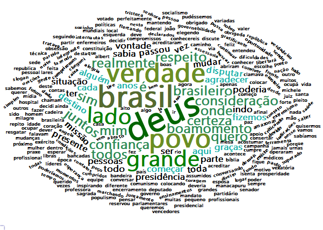

Fernando Haddad preferiu uma abordagem mais tradicional e [fez seu discurso pós-eleição em um hotel em São Paulo,](https://www.poder360.com.br/eleicoes/leia-a-integra-do-discurso-de-derrota-fernando-haddad/) com cobertura da imprensa. O termo mais comum de sua fala foi “todos”, seguido por “democracia”.

“Vamos defender nosso ponto de vista, respeitando a democracia, as instituições”, disse o candidato do PT.

Outra expressão bastante dita pelo petista foi “coragem”, em cinco oportunidades. Era uma forma de incentivar seus eleitores após os casos de violência ocorridos durante o segundo turno. “Senti uma angústia, um medo na expressão de muitas pessoas. Não tenham medo, nós estaremos aqui, nós estaremos juntos, nós estaremos de mãos dadas com vocês, nós abraçaremos a causa de vocês. Coragem, a vida é feita de coragem”, afirmou.

Analisando o discurso de Haddad, uma curiosidade, é que ele cita mais vezes o número 45 - associado ao PSDB (adversário histórico do PT), mas em alusão ao número de votos que recebeu - que o nome do ex-presidente Luiz Inácio Lula da Silva, dito uma única vez. Veja abaixo a nuvem de palavras do petista.

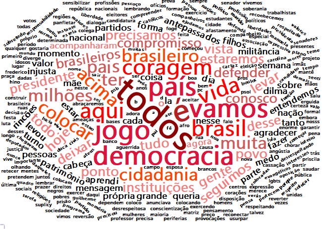